# Analysis on College Major selection depending on Income

# Introduction

In this analysis we will analyse if there is a correlation between income and the selection of college major categories.

A codebook for the dataset is given below:

- rank: Rank by median earnings
- major_code: Major code
- major: Major description
- major_category: Category of major
- total: Total number of people with major
- sample_size: Sample size of full-time, year-round individuals used for income/earnings estimates: p25th, median, p75th
- p25th: 25th percentile of earnings
- median: Median earnings of full-time, year-round workers
- p75th: 75th percentile of earnings
- perc_men: % men with major (out of total)
- perc_women: % women with major (out of total)
- perc_employed: % employed (out of total)
- perc_employed_fulltime: % employed 35 hours or more (out of employed)
- perc_employed_parttime: % employed less than 35 hours (out of employed)
- perc_employed_fulltime_yearround: % employed at least 50 weeks and at least 35 hours (out of employed and full-time)
- perc_unemployed: % unemployed (out of employed)
- perc_college_jobs: % with job requiring a college degree (out of employed)
- perc_non_college_jobs: % with job not requiring a college degree (out of employed)
- perc_low_wage_jobs: % in low-wage service jobs (out of total)

# Library loading and Data reading

```r
library(dplyr)
library(ggplot2)
library(collegeIncome)
data(college)
```

# Exploratory data analysis

```r
head(college)
```

|  | rank | major_code | major | major_category | total | sample_size | perc_women | p25th | median | p75th | perc_men | perc_employed | perc_employed_fulltime | perc_employed_parttime | perc_employed_fulltime_yearround | perc_unemployed | perc_college_jobs | perc_non_college_jobs | perc_low_wage_jobs |
| --- | --- | --- | --- | --- | --- | --- | --- | --- | --- | --- | --- | --- | --- | --- | --- | --- | --- | --- | --- |
| 1 | 1 | 2419 | Petroleum Engineering | Engineering | 2339 | 36 | 0.9109326 | 25000 | 40000 | 50000 | 0.08906743 | 0.9115044 | 0.9206524 | 0.1774785 | 0.7704431 | 0.08849558 | 0.6702970 | 0.1821782 | 0.05544554 |
| 2 | 2 | 2416 | Mining And Mineral Engineering | Engineering | 756 | 7 | 0.5154064 | 26000 | 37000 | 40000 | 0.48459355 | 0.7980501 | 0.7110092 | 0.3623853 | 0.7093101 | 0.20194986 | 0.3867764 | 0.5158761 | 0.21560172 |
| 3 | 3 | 2415 | Metallurgical Engineering | Engineering | 856 | 3 | 0.5942076 | 26700 | 45000 | 60000 | 0.40579235 | 0.7871943 | 0.8833498 | 0.3387257 | 0.7738366 | 0.21280567 | 0.7289116 | 0.1759983 | 0.03014828 |
| 4 | 4 | 2417 | Naval Architecture And Marine Engineering | Engineering | 1258 | 16 | 0.6521298 | 26000 | 35000 | 45000 | 0.34787018 | 0.8465608 | 0.9366337 | 0.1673267 | 0.6527853 | 0.15343915 | 0.2460902 | 0.4107636 | 0.04323827 |
| 5 | 5 | 2405 | Chemical Engineering | Engineering | 32260 | 289 | 0.4179248 | 31500 | 62000 | 109000 | 0.58207520 | 0.8515625 | 0.8086363 | 0.4020061 | 0.6852821 | 0.14843750 | 0.5867515 | 0.3860437 | 0.11801062 |
| 6 | 6 | 2418 | Nuclear Engineering | Engineering | 2573 | 17 | 0.4305368 | 23000 | 44700 | 50000 | 0.56946324 | 0.8474507 | 0.8756262 | 0.2040405 | 0.6567727 | 0.15254929 | 0.4624782 | 0.4057592 | 0.23472949 |

```r
str(college)
```

```
'data.frame':   173 obs. of  19 variables:
 $ rank                            : int  1 2 3 4 5 6 7 8 9 10 ...
 $ major_code                      : int  2419 2416 2415 2417 2405 2418 6202 5001 2414 2408 ...
 $ major                           : chr  "Petroleum Engineering" "Mining And Mineral Engineering" "Metallurgical Engineering" "Naval Architecture And Marine Engineering" ...
 $ major_category                  : chr  "Engineering" "Engineering" "Engineering" "Engineering" ...
 $ total                           : int  2339 756 856 1258 32260 2573 3777 1792 91227 81527 ...
 $ sample_size                     : int  36 7 3 16 289 17 51 10 1029 631 ...
 $ perc_women                      : num  0.911 0.515 0.594 0.652 0.418 ...
 $ p25th                           : num  25000 26000 26700 26000 31500 23000 32500 37900 29200 23000 ...
 $ median                          : num  40000 37000 45000 35000 62000 44700 45000 57000 36000 32200 ...
 $ p75th                           : num  50000 40000 60000 45000 109000 50000 58000 67000 46000 47100 ...
 $ perc_men                        : num  0.0891 0.4846 0.4058 0.3479 0.5821 ...
 $ perc_employed                   : num  0.912 0.798 0.787 0.847 0.852 ...
 $ perc_employed_fulltime          : num  0.921 0.711 0.883 0.937 0.809 ...
 $ perc_employed_parttime          : num  0.177 0.362 0.339 0.167 0.402 ...
 $ perc_employed_fulltime_yearround: num  0.77 0.709 0.774 0.653 0.685 ...
 $ perc_unemployed                 : num  0.0885 0.2019 0.2128 0.1534 0.1484 ...
 $ perc_college_jobs               : num  0.67 0.387 0.729 0.246 0.587 ...
 $ perc_non_college_jobs           : num  0.182 0.516 0.176 0.411 0.386 ...
 $ perc_low_wage_jobs              : num  0.0554 0.2156 0.0301 0.0432 0.118 ...
```

We can see that this dataframe contains 173 observations of 19 variables corresponding to the codebook. For my analysis only some of these variables are important including “major_category” and “median”.

I will start by converting the “major_category” to a factor variable:

```r
college$major_category <- as.factor(college$major_category)
```

We can then see the unique values of the categories:

```r
unique(college$major_category)
```

```
 [1] Engineering                         Business                            Physical Sciences                   Law & Public Policy                 Computers & Mathematics
 [6] Agriculture & Natural Resources     Industrial Arts & Consumer Services Arts                                Health                              Social Science
[11] Biology & Life Science              Education                           Humanities & Liberal Arts           Psychology & Social Work            Communications & Journalism
[16] Interdisciplinary
16 Levels: Agriculture & Natural Resources Arts Biology & Life Science Business Communications & Journalism Computers & Mathematics Education Engineering Health ... Social Science
```

I then proceed to analyze the medians of the incomes by major category:

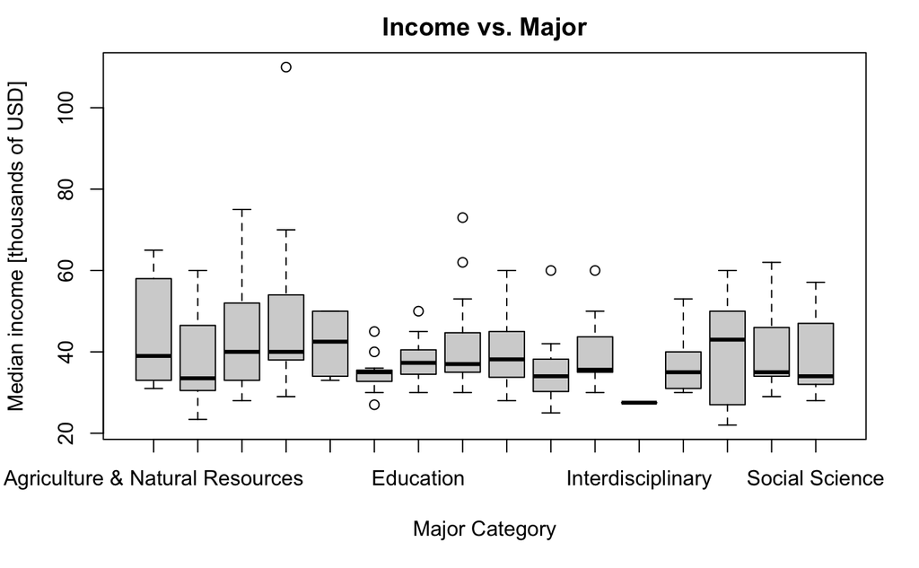

```r
boxplot(median/1000 ~ major_category, data = college, main = "Income vs. Major", ylab = "Median income [thousands of USD]", xlab = "Major Category")
```

We can induce from the boxplot that the distribution is skewed and not normal.

# Statistical Data Analysis & Regression Model

We proceed to order the categories alphabetically and fit a linear model to compare each median with the first one (Agriculture & Natural Resources):

```r
fit <- lm(median ~ major_category,data = college)
summary(fit)$coef
```

```
                                                     Estimate Std. Error     t value     Pr(>|t|)
(Intercept)                                        43500.0000   3590.819 12.11422804 2.873928e-24
major_categoryArts                                 -5450.0000   5386.228 -1.01183974 3.131715e-01
major_categoryBiology & Life Science                 364.2857   4701.486  0.07748311 9.383379e-01
major_categoryBusiness                              5653.8462   4776.236  1.18374520 2.383031e-01
major_categoryCommunications & Journalism          -1500.0000   6717.807 -0.22328715 8.236023e-01
major_categoryComputers & Mathematics              -8781.8182   4961.429 -1.77001776 7.866520e-02
major_categoryEducation                            -5562.5000   4577.414 -1.21520579 2.261119e-01
major_categoryEngineering                          -3106.8966   4164.154 -0.74610504 4.567197e-01
major_categoryHealth                               -3183.3333   4861.992 -0.65473851 5.135942e-01
major_categoryHumanities & Liberal Arts            -8333.3333   4635.727 -1.79763232 7.415704e-02
major_categoryIndustrial Arts & Consumer Services  -3071.4286   5595.887 -0.54887249 5.838727e-01
major_categoryInterdisciplinary                   -16000.0000  11909.399 -1.34347667 1.810563e-01
major_categoryLaw & Public Policy                  -5700.0000   6219.481 -0.91647520 3.608233e-01
major_categoryPhysical Sciences                    -3100.0000   5078.185 -0.61045434 5.424435e-01
major_categoryPsychology & Social Work             -3611.1111   5217.339 -0.69213657 4.898739e-01
major_categorySocial Science                       -4433.3333   5217.339 -0.84973074 3.967687e-01
```

From these coefficients we can induce that the median income for Agriculture students is $43500, and that there is no significant difference between the income medians of all other major categories is not statistically significant (using a p-value of 0.05).

Since business has the highest median income, we relevel the fit to compare all other categories with it:

```r
major_category_b <- relevel(college$major_category, "Business")
fitb <- lm(median ~ major_category_b, data = college)
summary(fitb)$coef
```

```
                                                      Estimate Std. Error   t value     Pr(>|t|)
(Intercept)                                          49153.846   3149.357 15.607584 9.444322e-34
major_category_bAgriculture & Natural Resources      -5653.846   4776.236 -1.183745 2.383031e-01
major_category_bArts                                -11103.846   5102.541 -2.176141 3.103954e-02
major_category_bBiology & Life Science               -5289.560   4373.606 -1.209428 2.283166e-01
major_category_bCommunications & Journalism          -7153.846   6492.565 -1.101852 2.722123e-01
major_category_bComputers & Mathematics             -14435.664   4651.908 -3.103171 2.271210e-03
major_category_bEducation                           -11216.346   4239.951 -2.645395 8.989341e-03
major_category_bEngineering                          -8760.743   3790.072 -2.311498 2.210557e-02
major_category_bHealth                               -8837.179   4545.705 -1.944073 5.367450e-02
major_category_bHumanities & Liberal Arts           -13987.179   4302.840 -3.250685 1.408831e-03
major_category_bIndustrial Arts & Consumer Services  -8725.275   5323.384 -1.639047 1.032059e-01
major_category_bInterdisciplinary                   -21653.846  11783.813 -1.837592 6.801278e-02
major_category_bLaw & Public Policy                 -11353.846   5975.484 -1.900071 5.925698e-02
major_category_bPhysical Sciences                    -8753.846   4776.236 -1.832792 6.872781e-02
major_category_bPsychology & Social Work             -9264.957   4923.931 -1.881618 6.173891e-02
major_category_bSocial Science                      -10087.179   4923.931 -2.048603 4.216615e-02
```

```r
pval <- summary(fitb)$coef[,4] < 0.025
pval
```

```
                                        (Intercept)     major_category_bAgriculture & Natural Resources                                major_category_bArts
                                               TRUE                                               FALSE                                               FALSE
             major_category_bBiology & Life Science         major_category_bCommunications & Journalism             major_category_bComputers & Mathematics
                                              FALSE                                               FALSE                                                TRUE
                          major_category_bEducation                         major_category_bEngineering                              major_category_bHealth
                                               TRUE                                                TRUE                                               FALSE
          major_category_bHumanities & Liberal Arts major_category_bIndustrial Arts & Consumer Services                   major_category_bInterdisciplinary
                                               TRUE                                               FALSE                                               FALSE
                major_category_bLaw & Public Policy                   major_category_bPhysical Sciences            major_category_bPsychology & Social Work
                                              FALSE                                               FALSE                                               FALSE
                     major_category_bSocial Science
                                              FALSE
```

```r
fit4l <- lm(median ~ major_category_b - 1, data = college)
summary(fit4l)$coef
```

```
                                                    Estimate Std. Error   t value     Pr(>|t|)
major_category_bBusiness                            49153.85   3149.357 15.607584 9.444322e-34
major_category_bAgriculture & Natural Resources     43500.00   3590.819 12.114228 2.873928e-24
major_category_bArts                                38050.00   4014.658  9.477769 3.919976e-17
major_category_bBiology & Life Science              43864.29   3034.796 14.453784 1.191360e-30
major_category_bCommunications & Journalism         42000.00   5677.583  7.397514 7.850192e-12
major_category_bComputers & Mathematics             34718.18   3423.712 10.140510 6.691567e-19
major_category_bEducation                           37937.50   2838.792 13.363961 1.095127e-27
major_category_bEngineering                         40393.10   2108.602 19.156348 6.199089e-43
major_category_bHealth                              40316.67   3277.954 12.299338 8.947526e-25
major_category_bHumanities & Liberal Arts           35166.67   2931.891 11.994532 6.110648e-24
major_category_bIndustrial Arts & Consumer Services 40428.57   4291.850  9.419848 5.577563e-17
major_category_bInterdisciplinary                   27500.00  11355.167  2.421805 1.658291e-02
major_category_bLaw & Public Policy                 37800.00   5078.185  7.443604 6.067423e-12
major_category_bPhysical Sciences                   40400.00   3590.819 11.250915 6.574192e-22
major_category_bPsychology & Social Work            39888.89   3785.056 10.538521 5.658611e-20
major_category_bSocial Science                      39066.67   3785.056 10.321293 2.183346e-19
```

In this case, we use 0.025 as a p-value since we want to see if the median income is significantly smaller or higher than that of Business major students, some categories do cross this threshold, these and their median income are:

[output not shown]

# Conclusion